# 03contrastive-analysis-solution.Rmd

Alena Pestova

2022-10-04

## All preprocessing, calculations of g2, ipm, log-odds etc. (code from the practice)

```r
library(readr)
sou <- read_csv("data/transcripts.csv")
library(dplyr)
democrats <- c("Woodrow Wilson", "Franklin D. Roosevelt", "Harry
S. Truman", "John F. Kennedy", "Lyndon B. Johnson", "Jimmy Carter",
"William J. Clinton", "Barack Obama")
sou.democrats <- sou %>%
    filter(president %in% democrats)
sou.republicans <- sou %>%
    filter(date > "1917-10-25" & !president %in% democrats)

library(stopwords)
library(tidytext)

sou.long.dem <- sou.democrats %>%
    unnest_tokens(words, transcript)

freq.list.dem <- sou.long.dem %>% dplyr::count(words, sort=TRUE)

enstopwords <- data.frame(words=stopwords("en"), stringsAsFactors=FALSE)
freq.list.dem <- freq.list.dem %>%
    anti_join(enstopwords)
freq.list.dem <- freq.list.dem %>% mutate(n2 = n/sum(n))

sou.long.rep <- sou.republicans %>%
    unnest_tokens(words, transcript)

freq.list.rep <- sou.long.rep %>% dplyr::count(words, sort=TRUE)

freq.list.rep <- freq.list.rep %>%
    anti_join(enstopwords)
freq.list.rep <- freq.list.rep %>% mutate(n2 = n/sum(n))


library(textstem)
library(stringr)

democrats.long <- sou.democrats %>%
    unnest_tokens(word, transcript) %>%
    mutate(lem = lemmatize_words(word)) %>%
    filter(! lem %in% stopwords("en")) %>%
    filter(! str_detect(lem, "[0-9]+")) %>%
    mutate(party = "democrat")


republicans.long <- sou.republicans %>%
    unnest_tokens(word, transcript) %>%
    mutate(lem = lemmatize_words(word)) %>%
    filter(! lem %in% stopwords("en")) %>%
    filter(! str_detect(lem, "[0-9]+")) %>%
    mutate(party = "republican")


library(tidyr)
party.lemmas <- bind_rows(democrats.long, republicans.long) %>%
    dplyr::count(lem, party) %>%
    spread(party, n, fill = 0) %>%
    dplyr::filter(democrat > 10 | republican > 10)


# the number of all words (lemmas) in democrats speaches
dem_num = sum(party.lemmas$democrat)
# in republicans
rep_num = sum(party.lemmas$republican)

party.ipms <- party.lemmas
party.ipms$democrat <- party.ipms $ democrat * ( 10e+6 / dem_num )
party.ipms$republican <- party.ipms $ republican * ( 10e+6 / rep_num )

# the correct version
g2 = function(a, b){
  c = sum(a) - a
  d = sum(b) - b
  a.exp = ((a+b)*(a+c))/(a+b+c+d)
  b.exp = ((a+b)*(b+d))/(a+b+c+d)
  c.exp = ((c+d)*(a+c))/(a+b+c+d)
  d.exp = ((c+d)*(b+d))/(a+b+c+d)
  G2 = 2*(a*log(a/a.exp+1e-7) + b*log(b/b.exp+1e-7) + c*log(c/c.exp+1e-7) + d*log(d/d.exp+1e-7))
}

party.g2 <- party.lemmas %>%
    mutate(g2=g2(democrat, republican)) %>%
    arrange(desc(g2)) %>%
    mutate(g2 = round(g2, 2))

party.g2
```

```
## # A tibble: 3,904 × 4
##    lem         democrat republican    g2
##    <chr>          <dbl>      <dbl> <dbl>
##  1 work            2429       1651  283.
##  2 expenditure      170        648  234.
##  3 federal         1120       2224  232.
##  4 free             417       1101  230.
##  5 college          332         79  206.
##  6 nuclear          540        214  197.
##  7 get              737        356  196.
##  8 government      1839       3162  192.
##  9 job             1171        711  190.
## 10 fy               118          0  181.
## # … with 3,894 more rows
```

```r
logratio <- function(a, b) {
    return(log2((a/sum(a)/(b/sum(b)))))
}

party.lr <- party.g2 %>%
    mutate(logodds = logratio(democrat, republican))

party.disproportion <- party.lr %>%
    dplyr::filter(democrat > 0 & republican > 0) %>%
    group_by(logodds < 0) %>%
    top_n(15, abs(logodds)) %>%
    ungroup()
```

## Task for you:

**1. Examine G2 values. Look at the top-30 most significant words for both parties. Draw the same graph as for log-odds. Compare two graphs.**

We can take our calculated g2 metric and multiply it by one if the word is specific to republicans (for example). This multiplication is necessary only for a graph.  
How can we define to which group word is specific to? We can use already calculated log-odds( logodds < 0 - specificity for republcans, logodds > 0 - specificity for democrats), or we can compare normalized frequencies in both parties (normalized by the corpus size or with IPM metric).

Here is an example with using logodds:

```r
party.lr$new_g2 <- ifelse(party.lr$logodds < 0, party.lr$g2 * -1, party.lr$g2)
```

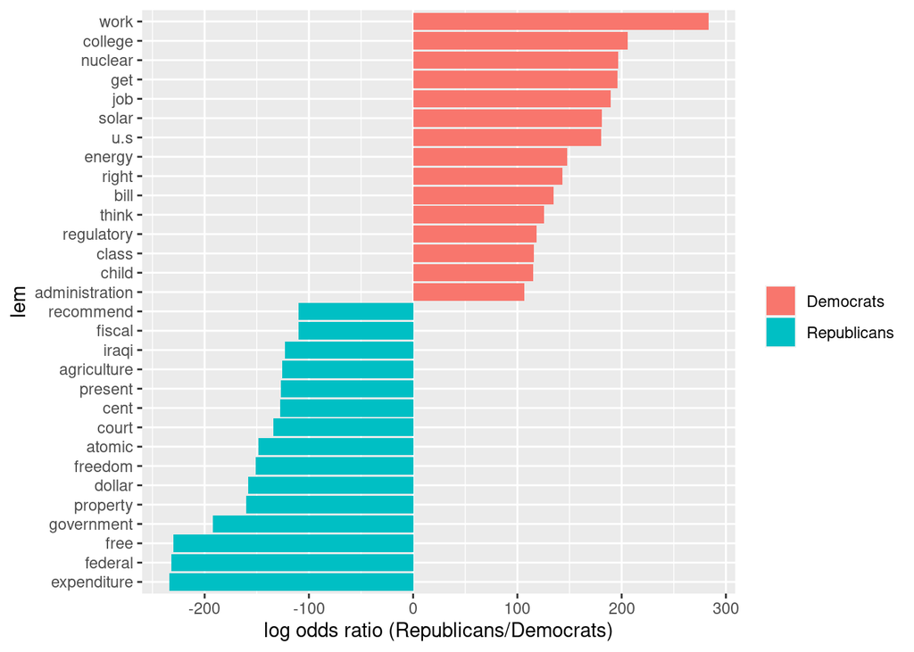

```r
library(ggplot2)

party.lr %>%
    filter(democrat > 0 & republican > 0) %>%
    group_by(new_g2 < 0) %>%
    top_n(15, abs(new_g2)) %>%
    ungroup() %>%
    mutate(lem = reorder(lem, new_g2)) %>%
    ggplot(aes(lem, new_g2, fill = new_g2 < 0)) +
    geom_col(show.legend = T) +
    coord_flip() +
    ylab("log odds ratio (Republicans/Democrats)") +
    scale_fill_discrete(name = "", labels = c("Democrats", "Republicans"))
```

Example with using normalized frequencies (IPM normalization):

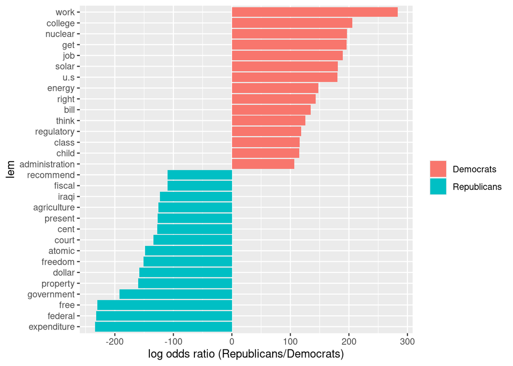

```r
# the number of all words (lemmas) in democrats and republicans speaches
dem_num = sum(party.lr$democrat)
rep_num = sum(party.lr$republican)

party.lr$democrat_norm <- party.lr $ democrat * ( 10e+6 / dem_num )
party.lr$republican_norm <- party.lr $ republican * ( 10e+6 / rep_num )

party.lr$new_g2_v2 = ifelse(party.lr$democrat_norm < party.lr$republican_norm, party.lr$g2 * (-1), party.lr$g2)

party.lr %>%
    filter(democrat > 0 & republican > 0) %>%
    group_by(new_g2_v2 < 0) %>%
    top_n(15, abs(new_g2_v2)) %>%
    ungroup() %>%
    mutate(lem = reorder(lem, new_g2_v2)) %>%
    ggplot(aes(lem, new_g2_v2, fill = new_g2_v2 < 0)) +
    geom_col(show.legend = T) +
    coord_flip() +
    ylab("log odds ratio (Republicans/Democrats)") +
    scale_fill_discrete(name = "", labels = c("Democrats", "Republicans"))
```

So, the graphs are similar. If we look at the values in two versions of calculating new g2, we will se that they are identical as well

```r
party.lr
```

```
## # A tibble: 3,904 × 9
##    lem         democrat republican    g2 logodds new_g2 democr…¹ repub…² new_g…³
##    <chr>          <dbl>      <dbl> <dbl>   <dbl>  <dbl>    <dbl>   <dbl>   <dbl>
##  1 work            2429       1651  283.   0.764   283.   68012.  40063.    283.
##  2 expenditure      170        648  234.  -1.72   -234.    4760.  15724.   -234.
##  3 federal         1120       2224  232.  -0.783  -232.   31360.  53967.   -232.
##  4 free             417       1101  230.  -1.19   -230.   11676.  26717.   -230.
##  5 college          332         79  206.   2.28    206.    9296.   1917.    206.
##  6 nuclear          540        214  197.   1.54    197.   15120.   5193.    197.
##  7 get              737        356  196.   1.26    196.   20636.   8639.    196.
##  8 government      1839       3162  192.  -0.575  -192.   51492.  76728.   -192.
##  9 job             1171        711  190.   0.926   190.   32788.  17253.    190.
## 10 fy               118          0  181. Inf       181.    3304.      0     181.
## # … with 3,894 more rows, and abbreviated variable names ¹democrat_norm,
## #   ²republican_norm, ³new_g2_v2
```

**2. Remember that G2 is the test statistic and you can calculate the statistical significance of the difference between word frequencies with it. Statistically significant difference at the level 0.05 for 2 words in corpora can be found of you take G2 > 3.84. Define the words which are statistically significant different using this method. Then, draw the same graph for log-odds but only for the words that are significantly different. Is there a difference between this and the previous graph for log odds ratio?**

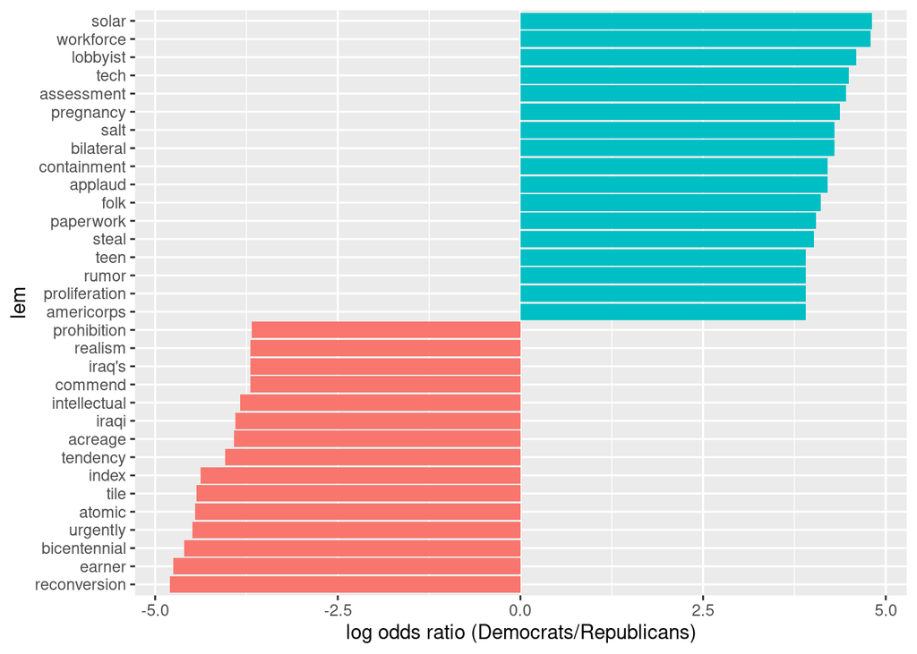

```r
data_filtered <- dplyr::filter(party.lr, g2 > 3.84)
data_filtered %>%
  filter(democrat > 0 & republican > 0) %>%
    group_by(logodds < 0) %>%
    top_n(15, abs(logodds)) %>%
    ungroup() %>%
    mutate(lem = reorder(lem, logodds)) %>%
    ggplot(aes(lem, logodds, fill = logodds > 0)) +
    geom_col(show.legend = FALSE) +
    coord_flip() +
    ylab("log odds ratio (Democrats/Republicans)") +
    scale_fill_discrete(name = "", labels = c("Democrats", "Republicans"))
```

Just filtering row with the value of g2 more than 3.84 and plotting.

original data

```r
nrow(party.lr)
```

```
## [1] 3904
```

```r
nrow(data_filtered)
```

```
## [1] 2068
```

**3. Work with PMI table. Calculate the frequency ratio for both parties (first slides of the lecture). Use different n (1, 100, 1000, 10000) as a constant that you add to frequencies and compare the results (the top words for each party). Draw the distributions of the ratios for each n.**

Caclulating ratios. Here we add different n as a constant to the IPM frequencies.

ratio = (democrat+n) / (republican + n)

```r
party.ipms <- party.ipms %>%
  mutate(ratio1 = (democrat+1)/(republican+1)) %>%
  mutate(ratio100 = (democrat+100)/(republican+100)) %>%
  mutate(ratio1000 = (democrat+1000)/(republican+1000)) %>%
  mutate(ratio10000 = (democrat+10000)/(republican+10000))
```

Drawing distributions

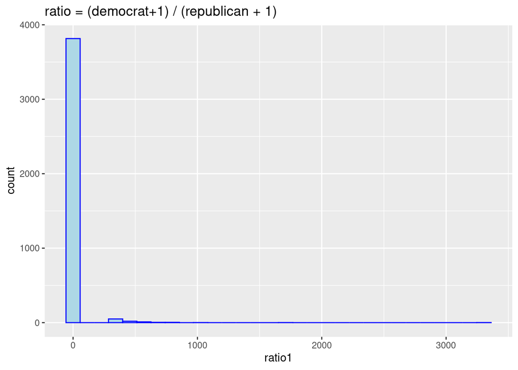

```r
ggplot()+
  geom_histogram(data=party.ipms, aes(ratio1), fill='light blue', col='blue')+
  ggtitle('ratio = (democrat+1) / (republican + 1)')
```

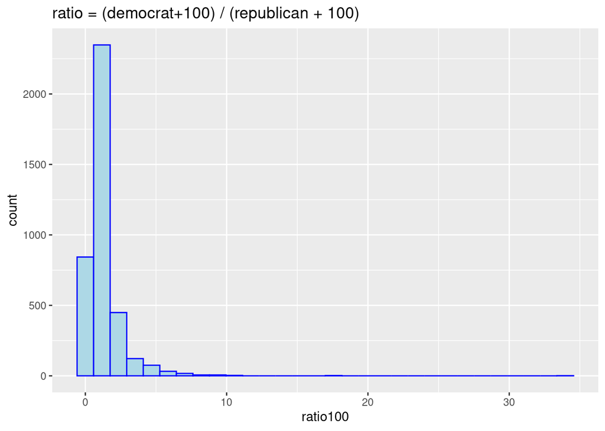

```r
ggplot()+
  geom_histogram(data=party.ipms, aes(ratio100), fill='light blue', col='blue')+
  ggtitle('ratio = (democrat+100) / (republican + 100)')
```

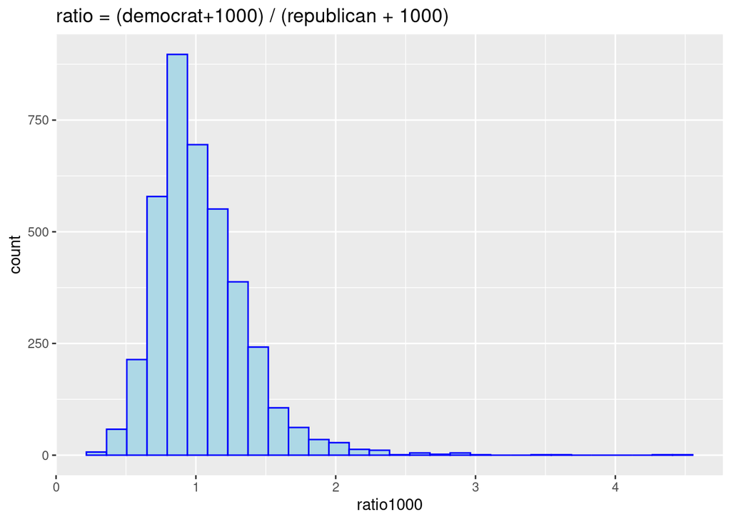

```r
ggplot()+
  geom_histogram(data=party.ipms, aes(ratio1000), fill='light blue', col='blue')+
  ggtitle('ratio = (democrat+1000) / (republican + 1000)')
```

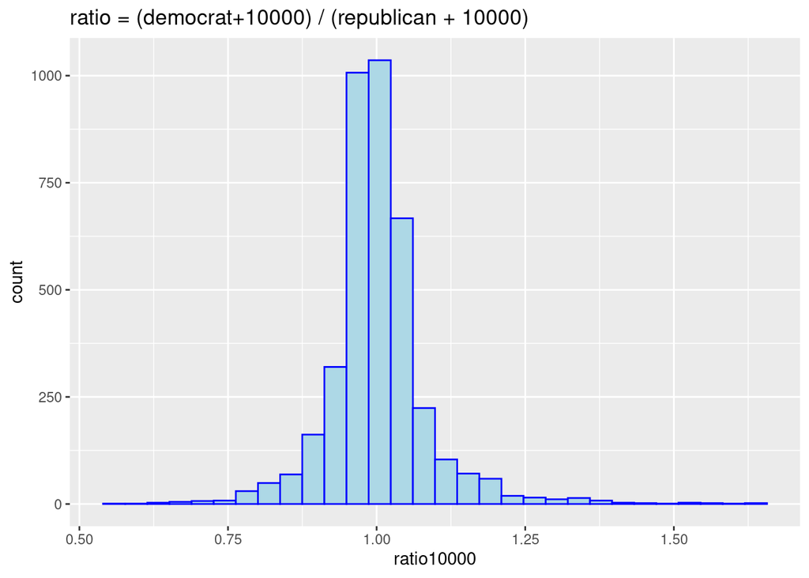

```r
ggplot()+
  geom_histogram(data=party.ipms, aes(ratio10000), fill='light blue', col='blue')+
  ggtitle('ratio = (democrat+10000) / (republican + 10000)')
```

What can we see here? With the increase of n: + range of ratios decreases + all ratios became more and more similar. They all go to 1.

With small n, there are some very big ratios that appear because of less frequent words (and words that appear only in one corpus). And it can be a problem (we have artificially inflated ratios for less frequent words). On the other side, with the very big n, all ratios become similar - this is also not we wanted from them because we want to use it as a measure for word specificity, but if all ratios are almost equal, this measure has no sense.

So, if you use this measure for extracting word specificity, you need to look for the suitable n, based on the task and possibly based on some subjective assessments.